# Computational Intelligence: Gebärdenspracherkennung mit Computer Vision

Milan Daniel Larsen

```python
!pip install tensorflow opencv-python mediapipe sklearn matplotlib
# Installation der benötigten packete
```

```python
!pip install -q git+https://github.com/tensorflow/docs
```

Importierung der benutzten libs:

```python
import cv2
import numpy as np
import os
from matplotlib import pyplot as plt
import matplotlib.image
import time
import mediapipe as mp
import itertools
import pandas as pd
import tensorflow as tf

import tqdm
import random
import pathlib
import json

import collections
from IPython.display import Video
from IPython.display import Image
from IPython.display import YouTubeVideo
# Some modules to display an animation using imageio.
import imageio
from IPython import display
from urllib import request

from tensorflow_docs.vis import embed
```

# 1. Detektierung der Landmarks mit MediaPipe

MediaPipe ist ein Framework von Google für auf visionärer KI basierende Anwendungen und ermöglicht es uns, Bewegungen der Hände und des Körpers einfach zu extrahieren. Dies erleichtert die korrekte Erkennung von Gesten im Vergleich zu ausschließlich durch ein CNN (Convolutional Neural Network). Dadurch reduziert sich auch die Datenmenge, die wir für eine ausreichend genaue Bestimmung der Gesten benötigen.

`mp_holistic` wird hier zur Detektion verwendet, während `mp_drawing` zum Zeichnen der Landmarks verwendet wird.

```python
mp_holistic = mp.solutions.holistic #Holistic model
mp_drawing = mp.solutions.drawing_utils # drawing utilities
```

Es wird eine Funktion "mediapip_detection" definiert. Diese verarbeitet ein Bild mit hilfe der MediaPipe und dem vorher definierten "holistic" Model. Das holistische Model ermöglicht es uns Haltung, Gesicht und Hände zu anaylsieren und zu erkennen.

```python
def mediapipe_detection(image,model):
    image = cv2.cvtColor(image,cv2.COLOR_BGR2RGB) # BGR zu RGB
    image.flags.writeable = False # Bild nicht mehr beschreibar
    results = model.process(image) #  MediaPipe auswetung
    image.flags.writeable = True # Bild wieder beschreibar
    image = cv2.cvtColor(image,cv2.COLOR_RGB2BGR) # RBG zu BGR
    return image, results # Bild und Ergebnis Zurückgeben
```

Anschließend wird die Funktion "draw_landmarks" implenentiert, die für die Darstellung der landmarks benutzt wird. Landmarks werden die verschiedenen Ankerpunkte des trackings genannt.

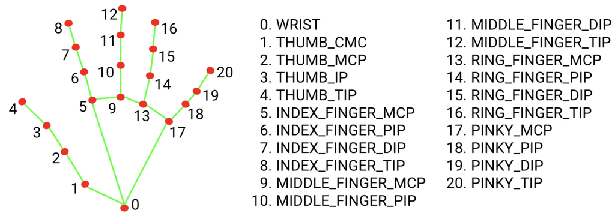

Für die Hand stehen 21 Landmarks zu Verfügung.

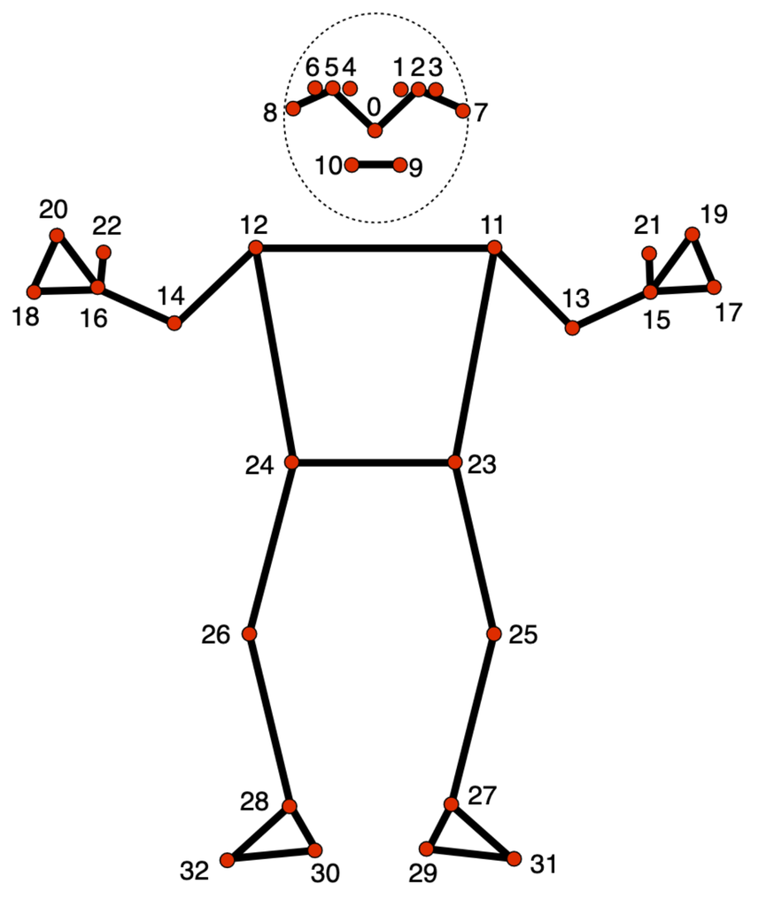

Für die pose stehen 33 landmarks zur verfügung

Über die Funktionen `draw_landmarks` und `draw_styled_landmarks` werden die Farben und Größen der Punkte und Linien festgelegt.

```python
def draw_landmarks(image,results):
    mp_drawing.draw_landmarks(image,results.face_landmarks,mp_holistic.FACEMESH_TESSELATION,
                             mp_drawing.DrawingSpec(color=(0,0,255),thickness=1,circle_radius=1), # Farbe der Punkte
                             mp_drawing.DrawingSpec(color=(250,206,135),thickness=1,circle_radius=4)) # Farbe des meshes
     # Draw pose connections
    mp_drawing.draw_landmarks(image, results.pose_landmarks, mp_holistic.POSE_CONNECTIONS,
                             mp_drawing.DrawingSpec(color=(80,22,10), thickness=2, circle_radius=4),
                             mp_drawing.DrawingSpec(color=(80,44,121), thickness=2, circle_radius=2)
                             )
    # Draw left hand connections
    mp_drawing.draw_landmarks(image, results.left_hand_landmarks, mp_holistic.HAND_CONNECTIONS,
                             mp_drawing.DrawingSpec(color=(121,22,76), thickness=2, circle_radius=4),
                             mp_drawing.DrawingSpec(color=(121,44,250), thickness=2, circle_radius=2)
                             )
     # Draw right hand connections
    mp_drawing.draw_landmarks(image, results.right_hand_landmarks, mp_holistic.HAND_CONNECTIONS,
                             mp_drawing.DrawingSpec(color=(245,117,66), thickness=2, circle_radius=4),
                             mp_drawing.DrawingSpec(color=(245,66,230), thickness=2, circle_radius=2)
                             )
```

```python
def draw_styled_landmarks(image, results):
    # Draw face connections
    mp_drawing.draw_landmarks(image, results.face_landmarks, mp_holistic.FACEMESH_TESSELATION,
                             mp_drawing.DrawingSpec(color=(80,110,10), thickness=1, circle_radius=1),
                             mp_drawing.DrawingSpec(color=(238,229,121), thickness=1, circle_radius=1)
                             )
    # Draw pose connections
    mp_drawing.draw_landmarks(image, results.pose_landmarks, mp_holistic.POSE_CONNECTIONS,
                             mp_drawing.DrawingSpec(color=(80,22,10), thickness=2, circle_radius=4),
                             mp_drawing.DrawingSpec(color=(80,44,121), thickness=2, circle_radius=2)
                             )
    # Draw left hand connections
    mp_drawing.draw_landmarks(image, results.left_hand_landmarks, mp_holistic.HAND_CONNECTIONS,
                             mp_drawing.DrawingSpec(color=(121,22,76), thickness=2, circle_radius=4),
                             mp_drawing.DrawingSpec(color=(121,44,250), thickness=2, circle_radius=2)
                             )
    # Draw right hand connections
    mp_drawing.draw_landmarks(image, results.right_hand_landmarks, mp_holistic.HAND_CONNECTIONS,
                             mp_drawing.DrawingSpec(color=(245,117,66), thickness=2, circle_radius=4),
                             mp_drawing.DrawingSpec(color=(245,66,230), thickness=2, circle_radius=2)
                             )
```

Als nächstes wird getestet ob das Model funktioniert. Dazu wird ein Video Stream der Webcam geöffnet und die einzelnen Frames über die Funktion `mediapipe_detection` analysiert. Anschließend werden die Landmarks mit der Funktion `draw_landmarks` gezeichnet und dann überr CV2 wiedergegeben. Über die 'q' Taste kann der Video-Feed beendet werden

```python
aufnahme =cv2.VideoCapture(1) # Webcam auswählen
with mp_holistic.Holistic(min_detection_confidence=0.5,min_tracking_confidence=0.5) as holistic:
    while aufnahme.isOpened():

        # Lesen der Webcam
        ret,frame =aufnahme.read()

        # Detektion
        image, results = mediapipe_detection(frame,holistic)
        myhand=results.left_hand_landmarks

        print(myhand)
        # Landmarks zeichnen
        draw_landmarks(image,results)
                # Abspielen des feeds
       # cv2.resize(image, (1000, 600))
        cv2.imshow('Ausgabe',image)


        # Abbrechen des Feedes
        if cv2.waitKey(10) & 0xFF == ord('q'):
            break
    aufnahme.release()
    cv2.destroyAllWindows()
```

[output not shown]

Das Ergebnis wird in einem NumPy Array abgespeichert und enthält die Koordinaten x,y und z für jeden Landmark.

```python
#len(results.left_hand_landmarks.landmark)
len(results.right_hand_landmark.landmark)
```

[output not shown]

```python
draw_landmarks(frame,results) # Landmarks auf image zeichnen
```

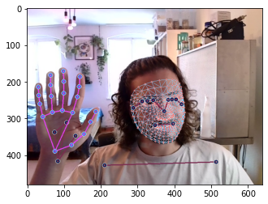

```python
plt.imshow(cv2.cvtColor(frame,cv2.COLOR_BGR2RGB)) #Ausgabe des Bildes
```

Folgendes Bild ist ein Test der Landmarks.

```python
# Filename
filename = 'savedImage.jpg'
cv2.imwrite(filename, frame)
```

```
True
```

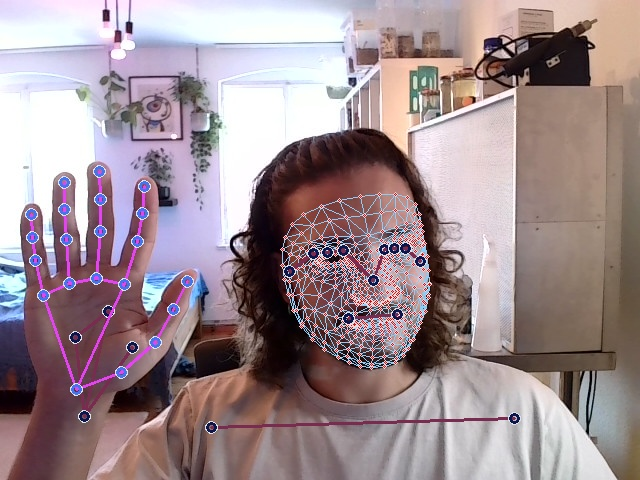

```python
Image(filename)
```

Durch das gut funktionierende MediaPipe ist selbst bei schlechten Lichtverhältnissen, wie in dem Beispiel mein Zimmer, eine Extraktion der Keypoints möglich.

```python
results.pose_landmarks.landmark[0].visibility
```

```
0.9999575018882751
```

# 2. Extraktion und Speicherung der Landmarks

Im Folgendem Kapitel sollen nun die Landmark Kooardinaten aus dem Ergebnis extrahiert werden und anschließend in NP-Arrays gespecihert werden.

Dies wir zunächst an der "Pose" getestet. Wir loopen dafür durch `results.pose_landmarks.landmark` und extrahieren für jede landmark `res.x, res.y, res.z, res.visibility`

```python
pose = []
for res in results.pose_landmarks.landmark:
    test = np.array([res.x, res.y, res.z, res.visibility])
    pose.append(test)
```

```python
pose
```

```
[array([ 0.53385872,  0.52968985, -1.192837  ,  0.9999575 ]),
 array([ 0.55340081,  0.45651576, -1.10547423,  0.99991459]),
 array([ 0.56896085,  0.45550197, -1.1055907 ,  0.99988139]),
 array([ 0.58610928,  0.45542282, -1.10553682,  0.99987268]),
 array([ 0.49504381,  0.46195862, -1.10708833,  0.99992472]),
 array([ 0.47101212,  0.46425799, -1.10665762,  0.99992561]),
 array([ 0.45033947,  0.46645832, -1.10695338,  0.99994147]),
 array([ 0.60047549,  0.48409003, -0.56440294,  0.99986196]),
 array([ 0.41750446,  0.4925338 , -0.55984634,  0.99995476]),
 array([ 0.56473947,  0.59842235, -0.99808198,  0.9999525 ]),
 array([ 0.49051866,  0.60229516, -0.99860126,  0.99996829]),
 array([ 0.72958583,  0.82625324, -0.23239768,  0.99816126]),
 array([ 0.28123814,  0.80405438, -0.30442855,  0.99913251]),
 array([ 0.86861354,  1.27275646, -0.20759368,  0.40048259]),
 array([ 0.04847405,  1.09404993, -0.91518086,  0.94220632]),
 array([ 0.88611746,  1.61606753, -0.56676215,  0.24908507]),
 array([ 0.16386388,  0.75920117, -2.02816176,  0.94199687]),
 array([ 0.91308004,  1.72860396, -0.67088664,  0.2821961 ]),
 array([ 0.18541551,  0.60481828, -2.27915454,  0.92618465]),
 array([ 0.86416566,  1.71004701, -0.73805851,  0.38009134]),
 array([ 0.2170786 ,  0.58336514, -2.21177649,  0.93782037]),
 array([ 0.83709764,  1.67573714, -0.6152721 ,  0.36763307]),
 array([ 0.23269013,  0.66196954, -2.0436666 ,  0.92947108]),
 array([ 6.36368692e-01,  1.64744139e+00, -7.04845712e-02,  5.00538503e-04]),
 array([3.22301298e-01, 1.64672554e+00, 7.50929266e-02, 6.05479057e-04]),
 array([ 6.27395630e-01,  2.33944654e+00, -1.69839382e-01,  6.79437944e-04]),
 array([ 3.38322043e-01,  2.34083676e+00, -4.01868597e-02,  4.88538994e-04]),
 array([6.17342055e-01, 2.95419574e+00, 5.05302310e-01, 6.46210319e-05]),
 array([3.44165027e-01, 2.94276452e+00, 3.83782744e-01, 1.28966503e-05]),
 array([6.21224105e-01, 3.04557753e+00, 5.23856819e-01, 2.37950153e-05]),
 array([3.41100782e-01, 3.02659369e+00, 4.06467378e-01, 2.20095972e-05]),
 array([ 5.79091191e-01,  3.13434863e+00, -2.20342919e-01,  3.92812108e-05]),
 array([ 3.73720348e-01,  3.13658190e+00, -3.84923518e-01,  6.94521150e-05])]
```

In dem NP-Array sind nun die Koordinaten gespeichert und der test war erfolgreich. Anschlließend wird der code noch refactored und auf die Restlichen landmarsk in "Face", "lh" für left hand und "rh".\ Ebenso muss abgefangen werden, dass das Array leer ist, wenn zb eine Hand nicht im Bild ist. Dazu wird ein Null-Array verwendet sollte ein landmark nicht existieren.

```python
pose = np.array([[res.x, res.y, res.z, res.visibility] for res in results.pose_landmarks.landmark]).flatten() if results.pose_landmarks else np.zeros(132)
face = np.array([[res.x, res.y, res.z] for res in results.face_landmarks.landmark]).flatten() if results.face_landmarks else np.zeros(1404)
lh = np.array([[res.x, res.y, res.z] for res in results.left_hand_landmarks.landmark]).flatten() if results.left_hand_landmarks else np.zeros(21*3)
rh = np.array([[res.x, res.y, res.z] for res in  results.right_hand_landmarks.landmark]).flatten() if results.right_hand_landmarks else np.zeros(21*3)
```

```python
pose.shape
```

```
(132,)
```

```python
def extract_keypoints(results):
    pose = np.array([[res.x, res.y, res.z, res.visibility] for res in results.pose_landmarks.landmark]).flatten() if results.pose_landmarks else np.zeros(33*4)
    face = np.array([[res.x, res.y, res.z] for res in results.face_landmarks.landmark]).flatten() if results.face_landmarks else np.zeros(468*3)
    lh = np.array([[res.x, res.y, res.z] for res in results.left_hand_landmarks.landmark]).flatten() if results.left_hand_landmarks else np.zeros(21*3)
    rh = np.array([[res.x, res.y, res.z] for res in results.right_hand_landmarks.landmark]).flatten() if results.right_hand_landmarks else np.zeros(21*3)
    return np.concatenate([pose, face, lh, rh])
```

Anschließend wird eine Funktion erstellt die uns die Landmarks extrahiert und in einem array zurückgibt.

# 3. Erstellung der Ordnerstruktur für Training und Testing

Um trainingsdaten aufzunehmen erstellen wir eine Ordnerstruktur, in dem die aufgezeichneten NP-Arrays abgespeichert werden. Als Grundlage für das Training sollen je Geste 30 Videos erstellt werden. Jedes Video besteht aus 30 Frames.

Ebenso werden die Gesten definiert, die erkannt werden sollen. In diesem Beispiel wollen wir "hi", "thanks", "i love you" und "do nothing" erkennen.

```python
# Speicherort
DATA_PATH = os.path.join('C://Users/milan/CI/Project/data_self/')

#actions = np.array(['Doing other things', 'Drumming Fingers', 'No gesture', 'Pulling Hand In','Pulling Two Fingers In','Pushing Hand Away','Pushing Hand Away','Pushing Two Fingers Away','Rolling Hand Backward','Rolling Hand Forward','Shaking Hand','Sliding Two Fingers Down','Sliding Two Fingers Left','Sliding Two Fingers Right','Sliding Two Fingers Up','Stop Sign','Swiping Down','Swiping Left','Swiping Right','Swiping Up','Thumb Down','Thumb Up','Turning Hand Clockwise','Turning Hand Counterclockwise','Zooming In With Full Hand','Zooming In With Two Fingers','Zooming Out With Full Hand','Zooming Out With Two Fingers'])

# Gesten definieren
#actions = np.array(['hi', 'thanks', 'iloveyou','do nothing'])
actions = np.array(['hi', 'thanks', 'iloveyou','donothing'])

# Anzahl der Videos
no_sequences = 30

# Anzahl der Frames pro Video
sequence_length = 30

# Folder start
start_folder = 30
```

```python
for action in actions:
    for sequence in range(no_sequences):
        try:
            os.makedirs(os.path.join(DATA_PATH, action, str(sequence)))
        except Exception as error:
             print("An error occurred:", error) # Ausgabe des Fehlers, falls Ordnererstellung fehlschlägt
```

[output not shown]

[output cut: 65 more lines]

[output not shown]

# 4. Aufnahme der Videos und Landmark Detektion

Im folgendem Abschnitt werden eigene Daten in Form von kleine, 30 Frames langen Videos aufgenommen und über CV analysiert. Mit der Media Pipe werden die Keypoints extrahiert.

```python
cam_feed = cv2.VideoCapture(1)
with mp_holistic.Holistic(min_detection_confidence=0.5, min_tracking_confidence=0.5) as holistic:

    # Loop through actions
    for action in actions:
        # Loop through sequences aka videos
        for sequence in range(no_sequences):
            # Loop through video length aka sequence length
            for frame_num in range(sequence_length):

                # Read feed
                ret, frame = cam_feed.read()

                # Landmarks Detektieren
                image, results = mediapipe_detection(frame, holistic)

                # Zeichnen der Landmarks
                draw_styled_landmarks(image, results)

                # NEW Apply wait logic
                if frame_num == 0:
                    cv2.putText(image, 'Start der Sequenz', (120,200),
                               cv2.FONT_HERSHEY_SIMPLEX, 1, (0,255, 0), 4, cv2.LINE_AA)
                    cv2.putText(image, 'Collecting frames for {} Video Number {}'.format(action, sequence), (15,12),
                               cv2.FONT_HERSHEY_SIMPLEX, 0.5, (0, 0, 255), 1, cv2.LINE_AA)
                    # Ausgabe des Feedes
                    cv2.imshow('Ausgabe', image)
                    cv2.waitKey(500)
                else:
                    cv2.putText(image, 'Collecting frames for {} Video Number {}'.format(action, sequence), (15,12),
                               cv2.FONT_HERSHEY_SIMPLEX, 0.5, (0, 0, 255), 1, cv2.LINE_AA)
                    # Show to screen
                    cv2.imshow('Ausgabe', image)

                # Landmark/Keypoint Extraktion
                keypoints = extract_keypoints(results) # Extraktion der keypoints
                npy_path = os.path.join(DATA_PATH, action, str(sequence), str(frame_num))
                np.save(npy_path, keypoints)

                # Break gracefully
                if cv2.waitKey(10) & 0xFF == ord('q'):
                    break

    cam_feed.release()
    cv2.destroyAllWindows()
```

Im nachfolgenden Video wird die Aufnahme der Clips für unser Netzwerk demonstriert. Für jede Aktion werden 30 Clips mit jeweils 30 Frames aufgezeichnet. Die jeweilige Aktion wird oben in der Leiste angezeigt, und vor jeder Aufnahme wird ein Text eingeblendet, der den Start der Aufnahme bestätigt.

```python
YouTubeVideo('2RghZ2d_P9A', width=800, height=300)
```

[video not shown]

# 5. Datenverarbeitung und Labels

Im Folgenden Kapitel werden nun die Daten, die gesammelt worden sind, weiter verarbeitet und ein Train/Test split erstellt. Mit dem einen Datensatz wird dann das Neural Netzt trainiert und mit dem andern getestet.

```python
from sklearn.model_selection import train_test_split
from tensorflow.keras.utils import to_categorical
```

```python
label_map = {label:num for num, label in enumerate(actions)}
```

```python
label_map
```

```
{'hi': 0, 'thanks': 1, 'iloveyou': 2, 'donothing': 3}
```

`Sequences` representiert hierbei unsere X-Werte und `labels` unser Y-Werte. Nun Speichern wir alle Np-Arrays, die wir vorher abgespeichert haben und fügen dies `Sequence` hinzu.

```python
sequences, labels = [], []
for action in actions:
    for sequence in range(no_sequences):
        window = []
        for frame_num in range(sequence_length):
            res = np.load(os.path.join(DATA_PATH, action, str(sequence), "{}.npy".format(frame_num)))
            window.append(res)
        sequences.append(window)
        labels.append(label_map[action])
```

Schauen wir uns nun die Form des Np-Arrrays an, sehen wir das wir 120 Clips, mit je 30 Frames und 1662 Keypoins haben.

```python
np.array(sequences).shape
```

```
(120, 30, 1662)
```

```python
np.array(labels).shape
```

```
(120,)
```

Es wird nun die `Sequences` in die X-Variable gespeichert

```python
X = np.array(sequences)
```

```python
X.shape
```

```
(120, 30, 1662)
```

Die labels werden nun noch von der in die Form eines Binary Flag gebracht.

```python
y = to_categorical(labels).astype(int)
```

Anschließend werden unsere Daten aufgeteilt in eine Test-Partition und Training-Partition.

```python
X_train, X_test, y_train, y_test = train_test_split(X, y, test_size=0.05)
```

```python
y_test.shape
```

```
(6, 4)
```

# 6. Training des LSTM Neuralen Netzwerkes

```python
from tensorflow.keras.models import Sequential
from tensorflow.keras.layers import LSTM, Dense
from tensorflow.keras.callbacks import TensorBoard
```

Über die Logdatein und TensorBoard können nacher das Training besser nachfolzogen werden.

```python
log_dir = os.path.join('Logs')
tb_callback = TensorBoard(log_dir=log_dir)
```

```python
actions.shape[0]
```

```
4
```

Für unser neuronales Netz werden insgesamt 6 Layer verwendet. Die ersten drei sind LSTM-Layer mit jeweils 64, 128 und 64 Units. Anschließend folgen drei Dense Layer.

LSTM (Long Short-Term Memory) ermöglicht uns, auf vergangene Informationen zuzugreifen und somit eine Sequenz von Frames zu analysieren, anstatt nur jeweils den aktuellen Schritt zur Verfügung zu haben. Dies verschafft uns bei Bewegungsabläufen, wie der Gestenerkennung, einen Vorteil.

```python
model = Sequential()
model.add(LSTM(64, return_sequences=True, activation='relu', input_shape=(30,1662)))
model.add(LSTM(128, return_sequences=True, activation='relu'))
model.add(LSTM(64, return_sequences=False, activation='relu'))
model.add(Dense(64, activation='relu'))
model.add(Dense(32, activation='relu'))
model.add(Dense(actions.shape[0], activation='softmax'))
```

```python
res = [.7, 0.2, 0.1]
```

```python
actions[np.argmax(res)]
```

```
'hi'
```

```python
model.compile(optimizer='Adam', loss='categorical_crossentropy', metrics=['categorical_accuracy'])
```

Das Model wird Compiliert und dann trainiert.

```python
model.fit(X_train, y_train, epochs=1000, callbacks=[tb_callback])
```

```
<keras.src.callbacks.History at 0x202503a6850>
```

```python
model.summary()
```

```
Model: "sequential"
_________________________________________________________________
 Layer (type)                Output Shape              Param #
=================================================================
 lstm (LSTM)                 (None, 30, 64)            442112

 lstm_1 (LSTM)               (None, 30, 128)           98816

 lstm_2 (LSTM)               (None, 64)                49408

 dense (Dense)               (None, 64)                4160

 dense_1 (Dense)             (None, 32)                2080

 dense_2 (Dense)             (None, 4)                 132

=================================================================
Total params: 596708 (2.28 MB)
Trainable params: 596708 (2.28 MB)
Non-trainable params: 0 (0.00 Byte)
_________________________________________________________________
```

# 7. Testen des Models

```python
res = model.predict(X_test)
```

```python
actions[np.argmax(res[2])]
```

```
'iloveyou'
```

```python
actions[np.argmax(y_test[2])]
```

```
'iloveyou'
```

Der Test war erfolgreich.

# 8. Abspeichern des Models

```python
model.save('action_27_09.keras')
```

```python
del model
```

```python
model.load_weights('action_27_09.keras')
```

# 9. Auswertung des Modells

```python
from sklearn.metrics import multilabel_confusion_matrix, accuracy_score
yhat = model.predict(X_test)
ytrue = np.argmax(y_test, axis=1).tolist()
yhat = np.argmax(yhat, axis=1).tolist()
multilabel_confusion_matrix(ytrue, yhat)

accuracy_score(ytrue, yhat)
```

```
1.0
```

Schaut man sich im Tensorboard die Log Files an, kann man die Genauigkeit des Models im Bezug auf die Trainingsdurchläuft betrachten. Es ist zu erkennen das bereits nach ca. 100 Epochs die Genauigkeit bei 1 liegt.

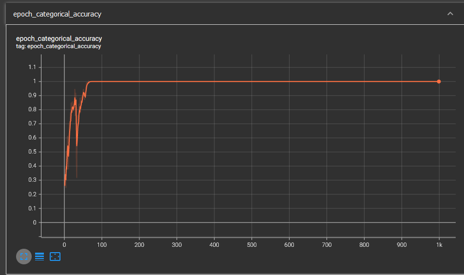

```python
Image('accuracy.png')
```

```python
colors = [(245,117,16), (117,245,16), (16,117,245),(16,117,245)]
def prob_viz(res, actions, input_frame, colors):
    output_frame = input_frame.copy()
    for num, prob in enumerate(res):
        cv2.rectangle(output_frame, (0,60+num*40), (int(prob*100), 90+num*40), colors[num], -1)
        cv2.putText(output_frame, actions[num], (0, 85+num*40), cv2.FONT_HERSHEY_SIMPLEX, 1, (255,255,255), 2, cv2.LINE_AA)

    return output_frame
```

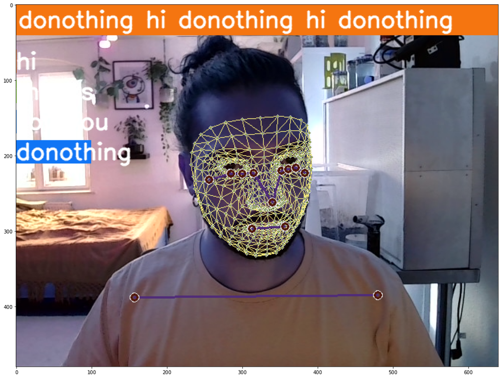

```python
plt.figure(figsize=(18,18))
plt.imshow(prob_viz(res, actions, image, colors))
```

```python
sequence.reverse()
len(sequence)
```

```
30
```

```python
sequence.append('def')
sequence.reverse()
sequence[-30:]
```

```
[array([ 0.63878042,  0.77517802, -0.88039219, ...,  0.        ,
         0.        ,  0.        ]),
 array([ 0.6389488 ,  0.7820217 , -1.17246222, ...,  0.        ,
         0.        ,  0.        ]),
 array([ 0.63916171,  0.78697717, -1.17701769, ...,  0.        ,
         0.        ,  0.        ]),
 array([ 0.63915646,  0.78820956, -1.13820517, ...,  0.        ,
         0.        ,  0.        ]),
 array([ 0.63925838,  0.79024285, -1.17714214, ...,  0.        ,
         0.        ,  0.        ]),
 array([ 0.63926214,  0.79140288, -1.18283582, ...,  0.        ,
         0.        ,  0.        ]),
 array([ 0.63945973,  0.79249358, -1.16811299, ...,  0.        ,
         0.        ,  0.        ]),
 array([ 0.63980472,  0.79241097, -1.18622291, ...,  0.        ,
         0.        ,  0.        ]),
 array([ 0.63972896,  0.79333174, -1.15552175, ...,  0.        ,
         0.        ,  0.        ]),
 array([ 0.63765407,  0.79366529, -1.14315689, ...,  0.        ,
         0.        ,  0.        ]),
 array([ 0.6351248 ,  0.79410177, -1.1643703 , ...,  0.        ,
         0.        ,  0.        ]),
 array([ 0.63440734,  0.7948131 , -1.1766001 , ...,  0.        ,
         0.        ,  0.        ]),
 array([ 0.6339528 ,  0.79496771, -1.17392349, ...,  0.        ,
         0.        ,  0.        ]),
 array([ 0.6333555 ,  0.79530162, -1.20124555, ...,  0.        ,
         0.        ,  0.        ]),
 array([ 0.63273656,  0.79556113, -1.16682696, ...,  0.        ,
         0.        ,  0.        ]),
 array([ 0.63264251,  0.79555339, -1.15407884, ...,  0.        ,
         0.        ,  0.        ]),
 array([ 0.6324231 ,  0.79481149, -1.09035325, ...,  0.        ,
         0.        ,  0.        ]),
 array([ 0.63271093,  0.79425311, -1.08461142, ...,  0.        ,
         0.        ,  0.        ]),
 array([ 0.63224781,  0.79425317, -1.09791923, ...,  0.        ,
         0.        ,  0.        ]),
 array([ 0.63215661,  0.79439938, -1.16892219, ...,  0.        ,
         0.        ,  0.        ]),
 array([ 0.63152319,  0.79445261, -1.17111337, ...,  0.        ,
         0.        ,  0.        ]),
 array([ 0.6314252 ,  0.79444861, -1.16503572, ...,  0.        ,
         0.        ,  0.        ]),
 array([ 0.63137597,  0.79448515, -1.1658622 , ...,  0.        ,
         0.        ,  0.        ]),
 array([ 0.63129365,  0.79442382, -1.18907678, ...,  0.        ,
         0.        ,  0.        ]),
 array([ 0.63105625,  0.79442412, -1.18250823, ...,  0.        ,
         0.        ,  0.        ]),
 array([ 0.63016826,  0.79432613, -1.1124332 , ...,  0.        ,
         0.        ,  0.        ]),
 array([ 0.63082218,  0.79312873, -1.09767377, ...,  0.        ,
         0.        ,  0.        ]),
 array([ 0.63082039,  0.79309326, -1.09371972, ...,  0.        ,
         0.        ,  0.        ]),
 array([ 0.63070583,  0.793639  , -1.16276646, ...,  0.        ,
         0.        ,  0.        ]),
 array([ 0.63071305,  0.79394746, -1.20138824, ...,  0.        ,
         0.        ,  0.        ])]
```

Anschließend wird das Modell mit dem Live-Feed der Webcam getestet. Dazu werden die Frames der Kamera mit der bereits bekannten Logik für die Detektion und das Zeichnen der Landmarks verarbeitet. Um eine Vorhersage zu treffen, werden die Keypoints von 30 Frames genutzt und in unser Modell mit model.predict() eingegeben.

Das Ergebnis wird dann in Form eines Balkendiagramms ausgegeben und oben in der Leiste angezeigt.

```python
# 1. New detection variables
sequence = []
sentence = []
threshold = 0.99

cap = cv2.VideoCapture(1)
# Mediapipe model
with mp_holistic.Holistic(min_detection_confidence=0.5, min_tracking_confidence=0.5) as holistic:
    while cap.isOpened():

        # Cam auslesen
        ret, frame = cap.read()

        # Detektieren
        image, results = mediapipe_detection(frame, holistic)
        print(results)

        # Landmarks zeichnen
        draw_styled_landmarks(image, results)

        # 2. Prediction logic
        keypoints = extract_keypoints(results)
#         sequence.insert(0,keypoints)
#         sequence = sequence[:30]
        sequence.append(keypoints)
        sequence = sequence[-30:]

        if len(sequence) == 30:
            res = model.predict(np.expand_dims(sequence, axis=0))[0]
            print(actions[np.argmax(res)])


        #3. Darstellung
            if res[np.argmax(res)] > threshold:
                if len(sentence) > 0:
                    if actions[np.argmax(res)] != sentence[-1]:
                        sentence.append(actions[np.argmax(res)])
                else:
                    sentence.append(actions[np.argmax(res)])

            if len(sentence) > 5:
                sentence = sentence[-5:]

            # Wahrscheinlichkeiten
            image = prob_viz(res, actions, image, colors)

        cv2.rectangle(image, (0,0), (640, 40), (245, 117, 16), -1)
        cv2.putText(image, ' '.join(sentence), (3,30),
                       cv2.FONT_HERSHEY_SIMPLEX, 1, (255, 255, 255), 2, cv2.LINE_AA)

        # Ausgabe
        cv2.imshow('OpenCV Feed', image)

        # Break gracefully
        if cv2.waitKey(10) & 0xFF == ord('q'):
            break
    cap.release()
    cv2.destroyAllWindows()
```

[output not shown]

[output cut: 416 more lines]

[output not shown]

Anschließend wird ein Video erstellt, in dem die Gestenerkennung getestet wird. Die Klassifizierung funktioniert relativ schnell und zuverlässig.

Durch den Einsatz von MediaPipe konnte mit einem vergleichsweise kleinen Datensatz ein gutes Ergebnis erzielt werden.

```python
YouTubeVideo('1HhjBqrnUkE', width=800, height=300)
```

[video not shown]